# POLS3316: Statistics for Political Scientists

Lecture 2: Variables, Units of Observation, Variable Types, Measures of Central Tendency

Instructor: Tom Hanna, Fall 2025

2026-01-27

## Descriptive Statistics

## Why do we use descriptive statistics?

- Explore the data
- See patterns in the data
- Communicate about the data

## What are the most basic things we need to know?

- What are the variables?
- What is the scope of the data (time, geography, cases)?
- What is the unit of observation?

## What are variables?

- In math (algebra) - a symbol that represents a number
- In science - a characteristic or attribute that can vary across units of observation
- In statistics - a characteristic or attribute that can vary across units of observation
- In R coding - a column in a *data frame*
- In all of the above - something that can take on different values

## What is a unit of observation?

- In science - the entity that is being measured
- In statistics - the entity that is being measured
- In R coding - a row in a *data frame*
- In all of the above - the thing that has the variable measured on/for it

## Putting it together

- Variables are characteristics or attributes that vary across units of observation

## Example

Titanic data

```
     Passenger_Type number_of_deaths
1    1st-Male-Child                0
2    2nd-Male-Child                0
3    3rd-Male-Child               35
4   Crew-Male-Child                0
5  1st-Female-Child                0
6  2nd-Female-Child                0
7  3rd-Female-Child               17
8 Crew-Female-Child                0
```

- units of observation
- variables: columns

## Wide format

**BEWARE! Not all data is formatted this way!** Sometimes you have to think “is this a variable or a unit of observation?”

For example, the following data on Scandinavian temperatures:

```
  country avgtemp.1994 avgtemp.1995 avgtemp.1996
1  Sweden            3            8            5
2 Denmark            9           11            8
3  Norway            9            5            9
```

It looks like the unit of observation is country and the variable is a combination of year and temperature.

## Long Format

If we look at it in long format, it’s a little clearer:

```
  country year avgtemp
1  Sweden 1994       3
2 Denmark 1994       9
3  Norway 1994       9
4  Sweden 1995       8
5 Denmark 1995      11
6  Norway 1995       5
7  Sweden 1996       5
8 Denmark 1996       8
9  Norway 1996       9
```

The variable is average temperature.

## Country-year format

```
  country_year avg_temp high_temp low_temp
1 Denmark-1994        9        12        4
2 Denmark-1995       11        14       10
3 Denmark-1996        8         9        7
4  Norway-1994        9        11        6
5  Norway-1995        5        10        1
6  Norway-1996        9        11        4
7  Sweden-1994        3         6        0
8  Sweden-1995        8        10        5
9  Sweden-1996        5         9        4
```

But the unit of observation is no longer country - it is country-year.

Beware again: This is *wide format* in statistical terms. This is *long format* in R *tidyverse* nomenclature.

## Measures of Central Tendency

Measures of central tendency help us:

- reveal patterns
- find the typical measurement
- find the center

## Measures of Central Tendency

**A few numbers that can summarize the center of measurement**

- Mean
- Median
- Mode

## Mean

- Symbol: $\bar{x}$
- Not the middle value
- Not the most common
- The center of mass - the sum above equals the sum below
- Formula is $\bar{x} = \frac{\sum X_i}{n}$
- Read that: The mean of X equals the sum of the observations (i) of X divided by the number (n) of observations.

## Example A:

A. What is the mean of 1,5,7,9,10,12,18

## Example A:

A. What is the mean of 1,5,7,9,10,12,18

```
[1] "Mean produced by sum function: 8.85714285714286"
```

```
[1] "Mean produced by mean function: 8.85714285714286"
```

## Example A:

A. What is the mean of 1,5,7,9,10,12,18

Center of mass

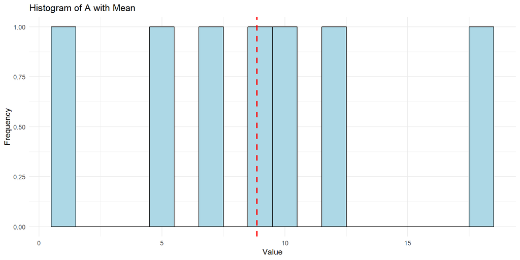

## Example B

B. What is the mean of 10,20,25,30,35,40,45,50,75

## Example B

B. What is the mean of 10,20,25,30,35,40,45,50,75

```
[1] 36.66667
```

```
[1] 36.66667
```

## Median

- Midpoint
- Half observations are greater, half are lower
- Just count
- Even observations - midpoint between middle two

## Example A

A - 1,5,7,9,10,12,18

## Example A:

A. What is the mean of 1,5,7,9,10,12,18

```
[1] "Median of A: 9"
```

## Example B

B - 10,20,25,30,35,40,45,50,75

## Example B

B - 10,20,25,30,35,40,45,50,75

```
[1] "Median of B: 35"
```

## Example B

B - 10,20,25,30,35,40,45,50,75

Midpoint and Center of Mass

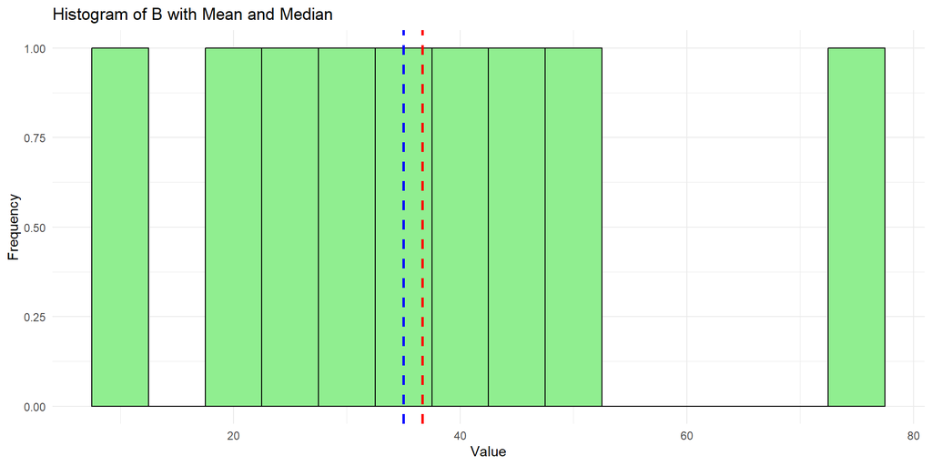

## Keep in mind for later

In both of our examples, the mean and median were close but not the same. That isn’t always the case.

## Mode

- Most common value
- Just count

## Examples:

C. 1,2,3,4,4,5,6,7

Answer:

D. 10,20,30,30,40,40,40,50,50,60,70

Answer:

## Advantages and disadvantages

- Median isn’t affected by outliers
- Mean gives the broader picture because it includes the outliers.
- Mode is the only option for *categorical variables*.

## Variable Types

- Categorical (nominal, ordinal)
- Numerical (interval, ratio)

## Variable Type Examples: Categorical

- Nominal (Order is meaningless)

  ```
    - Gender
    - Race
    - Religion
    - Democrat vs Republican (also binary)
  ```

- Ordinal (ORDer matters)

  ```
    - Education level
    - Income brackets
    - Likert scale responses
  ```

- Binary

  ```
    - Yes/No
    - 0/1
    - True/False
  ```

## Variable Type Examples: Numerical

- Interval (equal intervals, no true zero) *

  ```
    - Temperature (Celsius, Fahrenheit)
    - IQ scores
    - Calendar years
  ```

- Ratio (equal intervals, true zero) *

  ```
    - Height
    - Weight
    - Age
    - Income
    - Kelvin temperature
  ```

- Discrete (countable values)

  ```
    - Number of children
    - Number of countries in a trade agreement
    - Battle deaths in a conflict
  ```

## Social Science examples

- V-Dem v2x_libdem → ratio (0-1, true zero = no polyarchy) *
- Polity2 score (-10 to 10) → interval (0 not “no democracy”) *
- Country GDP → ratio *
- Year → interval
- Battle deaths (COW) → ratio/discrete *
- is_autocracy (0/1) → binary/categorical
- regime_type (dem/au/other) → nominal categorical
- freedom_level (low/med/high) → ordinal categorical

## Skewed distribution - when mean and median are different

**The three numbers are often different for the same sample or population.**

Example:

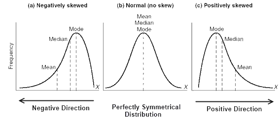

Negatively skewed, Normal, and Positively Skewed distributions

## Authorship and License

- Author: Tom Hanna
- Website: [tomhanna.me](https://tom-hanna.org/)

skewed distribution source: [Statistics by Jim](https://statisticsbyjim.com/)

- License: This work is licensed under a [Creative Commons Attribution-NonCommercial-ShareAlike 4.0 International License.](http://creativecommons.org/licenses/by-nc-sa/4.0/)